# Risk Factor Analysis

## Outcome Variable

**Outcome Variable:** whz

## Predictor Variables

**Intervention Variable:** hhwealth_quart

**Adjustment Set:**

- arm
- sex
- W_mage
- meducyrs
- feducyrs
- W_gagebrth
- W_birthwt
- W_birthlen
- W_nchldlt5
- W_parity
- delta_W_mage
- delta_meducyrs
- delta_feducyrs
- delta_W_gagebrth
- delta_W_birthwt
- delta_W_birthlen
- delta_W_nchldlt5
- delta_W_parity

## Stratifying Variables

The analysis was stratified on these variable(s):

- agecat
- studyid
- country

## Data Summary

| agecat | studyid | country | hhwealth_quart | n_cell | n |
| --- | --- | --- | --- | --- | --- |
| Birth | ki0047075b-MAL-ED | BANGLADESH | Wealth Q4 | 21 | 76 |
| Birth | ki0047075b-MAL-ED | BANGLADESH | Wealth Q1 | 17 | 76 |
| Birth | ki0047075b-MAL-ED | BANGLADESH | Wealth Q2 | 18 | 76 |
| Birth | ki0047075b-MAL-ED | BANGLADESH | Wealth Q3 | 20 | 76 |
| Birth | ki0047075b-MAL-ED | INDIA | Wealth Q4 | 11 | 54 |
| Birth | ki0047075b-MAL-ED | INDIA | Wealth Q1 | 17 | 54 |
| Birth | ki0047075b-MAL-ED | INDIA | Wealth Q2 | 15 | 54 |
| Birth | ki0047075b-MAL-ED | INDIA | Wealth Q3 | 11 | 54 |
| Birth | ki0047075b-MAL-ED | NEPAL | Wealth Q4 | 9 | 30 |
| Birth | ki0047075b-MAL-ED | NEPAL | Wealth Q1 | 8 | 30 |
| Birth | ki0047075b-MAL-ED | NEPAL | Wealth Q2 | 6 | 30 |
| Birth | ki0047075b-MAL-ED | NEPAL | Wealth Q3 | 7 | 30 |
| Birth | ki0047075b-MAL-ED | PERU | Wealth Q4 | 10 | 36 |
| Birth | ki0047075b-MAL-ED | PERU | Wealth Q1 | 9 | 36 |
| Birth | ki0047075b-MAL-ED | PERU | Wealth Q2 | 9 | 36 |
| Birth | ki0047075b-MAL-ED | PERU | Wealth Q3 | 8 | 36 |
| Birth | ki0047075b-MAL-ED | SOUTH AFRICA | Wealth Q4 | 15 | 61 |
| Birth | ki0047075b-MAL-ED | SOUTH AFRICA | Wealth Q1 | 16 | 61 |
| Birth | ki0047075b-MAL-ED | SOUTH AFRICA | Wealth Q2 | 14 | 61 |
| Birth | ki0047075b-MAL-ED | SOUTH AFRICA | Wealth Q3 | 16 | 61 |
| Birth | ki0047075b-MAL-ED | TANZANIA, UNITED REPUBLIC OF | Wealth Q4 | 5 | 23 |
| Birth | ki0047075b-MAL-ED | TANZANIA, UNITED REPUBLIC OF | Wealth Q1 | 6 | 23 |
| Birth | ki0047075b-MAL-ED | TANZANIA, UNITED REPUBLIC OF | Wealth Q2 | 7 | 23 |
| Birth | ki0047075b-MAL-ED | TANZANIA, UNITED REPUBLIC OF | Wealth Q3 | 5 | 23 |
| Birth | ki1000108-CMC-V-BCS-2002 | INDIA | Wealth Q4 | 31 | 88 |
| Birth | ki1000108-CMC-V-BCS-2002 | INDIA | Wealth Q1 | 12 | 88 |
| Birth | ki1000108-CMC-V-BCS-2002 | INDIA | Wealth Q2 | 20 | 88 |
| Birth | ki1000108-CMC-V-BCS-2002 | INDIA | Wealth Q3 | 25 | 88 |
| Birth | ki1000108-IRC | INDIA | Wealth Q4 | 79 | 343 |
| Birth | ki1000108-IRC | INDIA | Wealth Q1 | 90 | 343 |

[output cut: 158 more lines]

The following strata were considered:

- agecat: 24 months, studyid: ki0047075b-MAL-ED, country: BANGLADESH
- agecat: 24 months, studyid: ki0047075b-MAL-ED, country: INDIA
- agecat: 24 months, studyid: ki0047075b-MAL-ED, country: NEPAL
- agecat: 24 months, studyid: ki0047075b-MAL-ED, country: PERU
- agecat: 24 months, studyid: ki0047075b-MAL-ED, country: SOUTH AFRICA
- agecat: 24 months, studyid: ki0047075b-MAL-ED, country: TANZANIA, UNITED REPUBLIC OF
- agecat: 24 months, studyid: ki1000108-CMC-V-BCS-2002, country: INDIA
- agecat: 24 months, studyid: ki1000108-IRC, country: INDIA
- agecat: 24 months, studyid: ki1017093b-PROVIDE, country: BANGLADESH
- agecat: 24 months, studyid: ki1066203-TanzaniaChild2, country: TANZANIA, UNITED REPUBLIC OF
- agecat: 24 months, studyid: ki1113344-GMS-Nepal, country: NEPAL
- agecat: 24 months, studyid: ki1114097-CONTENT, country: PERU
- agecat: 24 months, studyid: ki1135781-COHORTS, country: GUATEMALA
- agecat: 24 months, studyid: ki1135781-COHORTS, country: PHILIPPINES
- agecat: 24 months, studyid: ki1148112-LCNI-5, country: MALAWI
- agecat: 24 months, studyid: kiGH5241-JiVitA-3, country: BANGLADESH
- agecat: 24 months, studyid: kiGH5241-JiVitA-4, country: BANGLADESH
- agecat: 6 months, studyid: ki0047075b-MAL-ED, country: BANGLADESH
- agecat: 6 months, studyid: ki0047075b-MAL-ED, country: INDIA
- agecat: 6 months, studyid: ki0047075b-MAL-ED, country: NEPAL
- agecat: 6 months, studyid: ki0047075b-MAL-ED, country: PERU
- agecat: 6 months, studyid: ki0047075b-MAL-ED, country: SOUTH AFRICA
- agecat: 6 months, studyid: ki0047075b-MAL-ED, country: TANZANIA, UNITED REPUBLIC OF
- agecat: 6 months, studyid: ki1000108-CMC-V-BCS-2002, country: INDIA
- agecat: 6 months, studyid: ki1000108-IRC, country: INDIA
- agecat: 6 months, studyid: ki1017093b-PROVIDE, country: BANGLADESH
- agecat: 6 months, studyid: ki1066203-TanzaniaChild2, country: TANZANIA, UNITED REPUBLIC OF
- agecat: 6 months, studyid: ki1113344-GMS-Nepal, country: NEPAL
- agecat: 6 months, studyid: ki1114097-CONTENT, country: PERU
- agecat: 6 months, studyid: ki1135781-COHORTS, country: GUATEMALA
- agecat: 6 months, studyid: ki1135781-COHORTS, country: PHILIPPINES
- agecat: 6 months, studyid: ki1148112-LCNI-5, country: MALAWI
- agecat: 6 months, studyid: kiGH5241-JiVitA-3, country: BANGLADESH
- agecat: 6 months, studyid: kiGH5241-JiVitA-4, country: BANGLADESH
- agecat: Birth, studyid: ki0047075b-MAL-ED, country: BANGLADESH
- agecat: Birth, studyid: ki0047075b-MAL-ED, country: INDIA
- agecat: Birth, studyid: ki0047075b-MAL-ED, country: NEPAL
- agecat: Birth, studyid: ki0047075b-MAL-ED, country: PERU
- agecat: Birth, studyid: ki0047075b-MAL-ED, country: SOUTH AFRICA
- agecat: Birth, studyid: ki0047075b-MAL-ED, country: TANZANIA, UNITED REPUBLIC OF
- agecat: Birth, studyid: ki1000108-CMC-V-BCS-2002, country: INDIA
- agecat: Birth, studyid: ki1000108-IRC, country: INDIA
- agecat: Birth, studyid: ki1114097-CONTENT, country: PERU
- agecat: Birth, studyid: ki1135781-COHORTS, country: GUATEMALA
- agecat: Birth, studyid: ki1135781-COHORTS, country: PHILIPPINES
- agecat: Birth, studyid: kiGH5241-JiVitA-3, country: BANGLADESH
- agecat: Birth, studyid: kiGH5241-JiVitA-4, country: BANGLADESH

### Dropped Strata

Some strata were dropped due to rare outcomes:

- agecat: Birth, studyid: ki1114097-CONTENT, country: PERU
- agecat: 24 months, studyid: ki1066203-TanzaniaChild2, country: TANZANIA, UNITED REPUBLIC OF

## Methods Detail

We’re interested in the causal parameters $E[Y_a]$ for all values of $a \in \mathcal{A}$. These parameters represent the mean outcome if, possibly contrary to fact, we intervened to set all units to have $A=a$. Under the randomization and positivity assumptions, these are identified by the statistical parameters $\psi_a=E_W[E_{Y|A,W}(Y|A=a,W)]$. In addition, we’re interested in the mean of $Y$, $E[Y]$ under no intervention (the observed mean). We will estimate these parameters by using SuperLearner to fit the relevant likelihood factors – $E_{Y|A,W}(Y|A=a,W)$ and $p(A=a|W)$, and then updating our likelihood fit using a joint TMLE.

For unadjusted analyses ($W=\{\}$), initial likelihoods were estimated using Lrnr_glm to estimate the simple $E(Y|A)$ and Lrnr_mean to estimate $p(A)$. For adjusted analyses, a small library containing Lrnr_glmnet, Lrnr_xgboost, and Lrnr_mean was used.

Having estimated these parameters, we will then use the delta method to estimate relative risks and attributable risks relative to a prespecified baseline level of $A$.

# Results Detail

## Results Plots

[figure not shown]

[figure not shown]

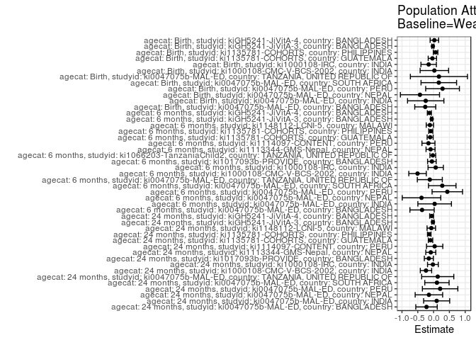

## Results Table

### Parameter: TSM

| agecat | studyid | country | intervention_level | baseline_level | estimate | ci_lower | ci_upper |
| --- | --- | --- | --- | --- | --- | --- | --- |
| Birth | ki0047075b-MAL-ED | BANGLADESH | Wealth Q4 | NA | -0.6780704 | -1.0308947 | -0.3252461 |
| Birth | ki0047075b-MAL-ED | BANGLADESH | Wealth Q1 | NA | -1.3630564 | -1.8198529 | -0.9062598 |
| Birth | ki0047075b-MAL-ED | BANGLADESH | Wealth Q2 | NA | -0.9935790 | -1.8212378 | -0.1659202 |
| Birth | ki0047075b-MAL-ED | BANGLADESH | Wealth Q3 | NA | -0.8170066 | -1.1065984 | -0.5274147 |
| Birth | ki0047075b-MAL-ED | INDIA | Wealth Q4 | NA | -0.8505149 | -1.4500355 | -0.2509944 |
| Birth | ki0047075b-MAL-ED | INDIA | Wealth Q1 | NA | -1.4698745 | -2.0346739 | -0.9050751 |
| Birth | ki0047075b-MAL-ED | INDIA | Wealth Q2 | NA | -0.9352965 | -1.6183742 | -0.2522188 |
| Birth | ki0047075b-MAL-ED | INDIA | Wealth Q3 | NA | -0.7836739 | -1.3991084 | -0.1682394 |
| Birth | ki0047075b-MAL-ED | NEPAL | Wealth Q4 | NA | -0.4188889 | -1.1801639 | 0.3423862 |
| Birth | ki0047075b-MAL-ED | NEPAL | Wealth Q1 | NA | -1.1812500 | -1.5597377 | -0.8027623 |
| Birth | ki0047075b-MAL-ED | NEPAL | Wealth Q2 | NA | -1.0533333 | -1.8600071 | -0.2466596 |
| Birth | ki0047075b-MAL-ED | NEPAL | Wealth Q3 | NA | -0.8500000 | -1.8133361 | 0.1133361 |
| Birth | ki0047075b-MAL-ED | PERU | Wealth Q4 | NA | -0.2070000 | -0.8370815 | 0.4230815 |
| Birth | ki0047075b-MAL-ED | PERU | Wealth Q1 | NA | -0.2566667 | -1.0027650 | 0.4894317 |
| Birth | ki0047075b-MAL-ED | PERU | Wealth Q2 | NA | 0.4544444 | -0.0496372 | 0.9585261 |
| Birth | ki0047075b-MAL-ED | PERU | Wealth Q3 | NA | 0.3812500 | -0.1703600 | 0.9328600 |
| Birth | ki0047075b-MAL-ED | SOUTH AFRICA | Wealth Q4 | NA | -0.2699569 | -0.8961403 | 0.3562265 |
| Birth | ki0047075b-MAL-ED | SOUTH AFRICA | Wealth Q1 | NA | -0.0061296 | -0.8559792 | 0.8437200 |
| Birth | ki0047075b-MAL-ED | SOUTH AFRICA | Wealth Q2 | NA | -0.3693191 | -0.9158238 | 0.1771855 |
| Birth | ki0047075b-MAL-ED | SOUTH AFRICA | Wealth Q3 | NA | 0.3080191 | -0.3400622 | 0.9561005 |
| Birth | ki0047075b-MAL-ED | TANZANIA, UNITED REPUBLIC OF | Wealth Q4 | NA | 0.4240000 | -0.6034412 | 1.4514412 |
| Birth | ki0047075b-MAL-ED | TANZANIA, UNITED REPUBLIC OF | Wealth Q1 | NA | 1.0250000 | 0.4445131 | 1.6054869 |
| Birth | ki0047075b-MAL-ED | TANZANIA, UNITED REPUBLIC OF | Wealth Q2 | NA | 0.4742857 | -0.1398244 | 1.0883959 |
| Birth | ki0047075b-MAL-ED | TANZANIA, UNITED REPUBLIC OF | Wealth Q3 | NA | 0.4100000 | -1.0412048 | 1.8612048 |
| Birth | ki1000108-CMC-V-BCS-2002 | INDIA | Wealth Q4 | NA | -0.6525060 | -1.2900166 | -0.0149953 |
| Birth | ki1000108-CMC-V-BCS-2002 | INDIA | Wealth Q1 | NA | -0.7050227 | -1.3799548 | -0.0300906 |
| Birth | ki1000108-CMC-V-BCS-2002 | INDIA | Wealth Q2 | NA | -0.9468858 | -1.5051865 | -0.3885852 |
| Birth | ki1000108-CMC-V-BCS-2002 | INDIA | Wealth Q3 | NA | -0.5943075 | -1.2269651 | 0.0383500 |
| Birth | ki1000108-IRC | INDIA | Wealth Q4 | NA | -0.8548156 | -1.1305196 | -0.5791115 |
| Birth | ki1000108-IRC | INDIA | Wealth Q1 | NA | -1.3455818 | -1.6519808 | -1.0391828 |

[output cut: 150 more lines]

### Parameter: E(Y)

| agecat | studyid | country | intervention_level | baseline_level | estimate | ci_lower | ci_upper |
| --- | --- | --- | --- | --- | --- | --- | --- |
| Birth | ki0047075b-MAL-ED | BANGLADESH | NA | NA | -0.9414474 | -1.1655223 | -0.7173724 |
| Birth | ki0047075b-MAL-ED | INDIA | NA | NA | -1.0992593 | -1.4060416 | -0.7924769 |
| Birth | ki0047075b-MAL-ED | NEPAL | NA | NA | -0.8496667 | -1.2385841 | -0.4607492 |
| Birth | ki0047075b-MAL-ED | PERU | NA | NA | 0.0766667 | -0.2519852 | 0.4053186 |
| Birth | ki0047075b-MAL-ED | SOUTH AFRICA | NA | NA | -0.1047541 | -0.4290621 | 0.2195539 |
| Birth | ki0047075b-MAL-ED | TANZANIA, UNITED REPUBLIC OF | NA | NA | 0.5930435 | 0.1251922 | 1.0608948 |
| Birth | ki1000108-CMC-V-BCS-2002 | INDIA | NA | NA | -0.6275000 | -0.9746292 | -0.2803708 |
| Birth | ki1000108-IRC | INDIA | NA | NA | -1.0105831 | -1.1973019 | -0.8238643 |
| Birth | ki1135781-COHORTS | GUATEMALA | NA | NA | -1.0572840 | -1.1606089 | -0.9539590 |
| Birth | ki1135781-COHORTS | PHILIPPINES | NA | NA | -0.7422912 | -0.7886598 | -0.6959226 |
| Birth | kiGH5241-JiVitA-3 | BANGLADESH | NA | NA | -0.7239386 | -0.7437757 | -0.7041015 |
| Birth | kiGH5241-JiVitA-4 | BANGLADESH | NA | NA | -0.3683163 | -0.4490504 | -0.2875821 |
| 6 months | ki0047075b-MAL-ED | BANGLADESH | NA | NA | -0.2054115 | -0.4495784 | 0.0387554 |
| 6 months | ki0047075b-MAL-ED | INDIA | NA | NA | -0.7227934 | -0.9900648 | -0.4555221 |
| 6 months | ki0047075b-MAL-ED | NEPAL | NA | NA | 0.0465079 | -0.2108391 | 0.3038550 |
| 6 months | ki0047075b-MAL-ED | PERU | NA | NA | 0.8727778 | 0.5137098 | 1.2318457 |
| 6 months | ki0047075b-MAL-ED | SOUTH AFRICA | NA | NA | 0.4787179 | 0.2126042 | 0.7448317 |
| 6 months | ki0047075b-MAL-ED | TANZANIA, UNITED REPUBLIC OF | NA | NA | 0.5033333 | 0.2619074 | 0.7447593 |
| 6 months | ki1000108-CMC-V-BCS-2002 | INDIA | NA | NA | -0.5026766 | -0.6536848 | -0.3516685 |
| 6 months | ki1000108-IRC | INDIA | NA | NA | -0.5989297 | -0.7344491 | -0.4634104 |
| 6 months | ki1017093b-PROVIDE | BANGLADESH | NA | NA | -0.2080201 | -0.2927357 | -0.1233045 |
| 6 months | ki1066203-TanzaniaChild2 | TANZANIA, UNITED REPUBLIC OF | NA | NA | 0.0801680 | 0.0273223 | 0.1330136 |
| 6 months | ki1113344-GMS-Nepal | NEPAL | NA | NA | -0.6047987 | -0.6909649 | -0.5186325 |
| 6 months | ki1114097-CONTENT | PERU | NA | NA | 1.0684318 | 0.9515274 | 1.1853362 |
| 6 months | ki1135781-COHORTS | GUATEMALA | NA | NA | 0.1914471 | 0.1185005 | 0.2643936 |
| 6 months | ki1135781-COHORTS | PHILIPPINES | NA | NA | -0.2938433 | -0.3352064 | -0.2524802 |
| 6 months | ki1148112-LCNI-5 | MALAWI | NA | NA | 0.4418137 | 0.3703100 | 0.5133174 |
| 6 months | kiGH5241-JiVitA-3 | BANGLADESH | NA | NA | -0.5932502 | -0.6127743 | -0.5737261 |
| 6 months | kiGH5241-JiVitA-4 | BANGLADESH | NA | NA | -0.3901595 | -0.4274150 | -0.3529041 |
| 24 months | ki0047075b-MAL-ED | BANGLADESH | NA | NA | -0.7648701 | -0.9729655 | -0.5567748 |
| 24 months | ki0047075b-MAL-ED | INDIA | NA | NA | -0.9125352 | -1.1472376 | -0.6778328 |
| 24 months | ki0047075b-MAL-ED | NEPAL | NA | NA | -0.3526190 | -0.5782459 | -0.1269921 |
| 24 months | ki0047075b-MAL-ED | PERU | NA | NA | -0.0095313 | -0.3657847 | 0.3467222 |
| 24 months | ki0047075b-MAL-ED | SOUTH AFRICA | NA | NA | 0.3131818 | 0.1018345 | 0.5245291 |
| 24 months | ki0047075b-MAL-ED | TANZANIA, UNITED REPUBLIC OF | NA | NA | -0.0049153 | -0.2462498 | 0.2364193 |
| 24 months | ki1000108-CMC-V-BCS-2002 | INDIA | NA | NA | -0.5571505 | -0.6585247 | -0.4557763 |
| 24 months | ki1000108-IRC | INDIA | NA | NA | -0.7458150 | -0.8368180 | -0.6548120 |
| 24 months | ki1017093b-PROVIDE | BANGLADESH | NA | NA | -0.8896187 | -0.9726240 | -0.8066134 |
| 24 months | ki1113344-GMS-Nepal | NEPAL | NA | NA | -1.1315863 | -1.2192240 | -1.0439487 |
| 24 months | ki1114097-CONTENT | PERU | NA | NA | 0.5668293 | 0.4302437 | 0.7034148 |
| 24 months | ki1135781-COHORTS | GUATEMALA | NA | NA | -0.2791396 | -0.3336899 | -0.2245893 |
| 24 months | ki1135781-COHORTS | PHILIPPINES | NA | NA | -0.6099592 | -0.6467541 | -0.5731643 |
| 24 months | ki1148112-LCNI-5 | MALAWI | NA | NA | -0.0478674 | -0.1301904 | 0.0344557 |
| 24 months | kiGH5241-JiVitA-3 | BANGLADESH | NA | NA | -1.2973086 | -1.3206115 | -1.2740057 |
| 24 months | kiGH5241-JiVitA-4 | BANGLADESH | NA | NA | -1.2231776 | -1.2550332 | -1.1913220 |

### Parameter: ATE

| agecat | studyid | country | intervention_level | baseline_level | estimate | ci_lower | ci_upper |
| --- | --- | --- | --- | --- | --- | --- | --- |
| Birth | ki0047075b-MAL-ED | BANGLADESH | Wealth Q4 | Wealth Q4 | 0.0000000 | 0.0000000 | 0.0000000 |
| Birth | ki0047075b-MAL-ED | BANGLADESH | Wealth Q1 | Wealth Q4 | -0.6849860 | -1.2654130 | -0.1045589 |
| Birth | ki0047075b-MAL-ED | BANGLADESH | Wealth Q2 | Wealth Q4 | -0.3155086 | -1.2200325 | 0.5890153 |
| Birth | ki0047075b-MAL-ED | BANGLADESH | Wealth Q3 | Wealth Q4 | -0.1389362 | -0.5846974 | 0.3068250 |
| Birth | ki0047075b-MAL-ED | INDIA | Wealth Q4 | Wealth Q4 | 0.0000000 | 0.0000000 | 0.0000000 |
| Birth | ki0047075b-MAL-ED | INDIA | Wealth Q1 | Wealth Q4 | -0.6193596 | -1.4468155 | 0.2080964 |
| Birth | ki0047075b-MAL-ED | INDIA | Wealth Q2 | Wealth Q4 | -0.0847815 | -0.9985522 | 0.8289891 |
| Birth | ki0047075b-MAL-ED | INDIA | Wealth Q3 | Wealth Q4 | 0.0668411 | -0.7922809 | 0.9259630 |
| Birth | ki0047075b-MAL-ED | NEPAL | Wealth Q4 | Wealth Q4 | 0.0000000 | 0.0000000 | 0.0000000 |
| Birth | ki0047075b-MAL-ED | NEPAL | Wealth Q1 | Wealth Q4 | -0.7623611 | -1.6125332 | 0.0878110 |
| Birth | ki0047075b-MAL-ED | NEPAL | Wealth Q2 | Wealth Q4 | -0.6344444 | -1.7436163 | 0.4747274 |
| Birth | ki0047075b-MAL-ED | NEPAL | Wealth Q3 | Wealth Q4 | -0.4311111 | -1.6589369 | 0.7967147 |
| Birth | ki0047075b-MAL-ED | PERU | Wealth Q4 | Wealth Q4 | 0.0000000 | 0.0000000 | 0.0000000 |
| Birth | ki0047075b-MAL-ED | PERU | Wealth Q1 | Wealth Q4 | -0.0496667 | -1.0262246 | 0.9268913 |
| Birth | ki0047075b-MAL-ED | PERU | Wealth Q2 | Wealth Q4 | 0.6614444 | -0.1454639 | 1.4683527 |
| Birth | ki0047075b-MAL-ED | PERU | Wealth Q3 | Wealth Q4 | 0.5882500 | -0.2491724 | 1.4256724 |
| Birth | ki0047075b-MAL-ED | SOUTH AFRICA | Wealth Q4 | Wealth Q4 | 0.0000000 | 0.0000000 | 0.0000000 |
| Birth | ki0047075b-MAL-ED | SOUTH AFRICA | Wealth Q1 | Wealth Q4 | 0.2638273 | -0.7971825 | 1.3248371 |
| Birth | ki0047075b-MAL-ED | SOUTH AFRICA | Wealth Q2 | Wealth Q4 | -0.0993622 | -0.9326086 | 0.7338841 |
| Birth | ki0047075b-MAL-ED | SOUTH AFRICA | Wealth Q3 | Wealth Q4 | 0.5779760 | -0.3203094 | 1.4762614 |
| Birth | ki0047075b-MAL-ED | TANZANIA, UNITED REPUBLIC OF | Wealth Q4 | Wealth Q4 | 0.0000000 | 0.0000000 | 0.0000000 |
| Birth | ki0047075b-MAL-ED | TANZANIA, UNITED REPUBLIC OF | Wealth Q1 | Wealth Q4 | 0.6010000 | -0.5790849 | 1.7810849 |
| Birth | ki0047075b-MAL-ED | TANZANIA, UNITED REPUBLIC OF | Wealth Q2 | Wealth Q4 | 0.0502857 | -1.1466966 | 1.2472680 |
| Birth | ki0047075b-MAL-ED | TANZANIA, UNITED REPUBLIC OF | Wealth Q3 | Wealth Q4 | -0.0140000 | -1.7920975 | 1.7640975 |
| Birth | ki1000108-CMC-V-BCS-2002 | INDIA | Wealth Q4 | Wealth Q4 | 0.0000000 | 0.0000000 | 0.0000000 |
| Birth | ki1000108-CMC-V-BCS-2002 | INDIA | Wealth Q1 | Wealth Q4 | -0.0525167 | -0.9609293 | 0.8558959 |
| Birth | ki1000108-CMC-V-BCS-2002 | INDIA | Wealth Q2 | Wealth Q4 | -0.2943799 | -1.1115603 | 0.5228006 |
| Birth | ki1000108-CMC-V-BCS-2002 | INDIA | Wealth Q3 | Wealth Q4 | 0.0581984 | -0.7698828 | 0.8862797 |
| Birth | ki1000108-IRC | INDIA | Wealth Q4 | Wealth Q4 | 0.0000000 | 0.0000000 | 0.0000000 |
| Birth | ki1000108-IRC | INDIA | Wealth Q1 | Wealth Q4 | -0.4907662 | -0.8775219 | -0.1040105 |

[output cut: 150 more lines]

### Parameter: PAR

| agecat | studyid | country | intervention_level | baseline_level | estimate | ci_lower | ci_upper |
| --- | --- | --- | --- | --- | --- | --- | --- |
| Birth | ki0047075b-MAL-ED | BANGLADESH | Wealth Q4 | NA | -0.2633770 | -0.5955810 | 0.0688271 |
| Birth | ki0047075b-MAL-ED | INDIA | Wealth Q4 | NA | -0.2487443 | -0.8238527 | 0.3263641 |
| Birth | ki0047075b-MAL-ED | NEPAL | Wealth Q4 | NA | -0.4307778 | -1.0497064 | 0.1881508 |
| Birth | ki0047075b-MAL-ED | PERU | Wealth Q4 | NA | 0.2836667 | -0.2496791 | 0.8170124 |
| Birth | ki0047075b-MAL-ED | SOUTH AFRICA | Wealth Q4 | NA | 0.1652028 | -0.3971486 | 0.7275542 |
| Birth | ki0047075b-MAL-ED | TANZANIA, UNITED REPUBLIC OF | Wealth Q4 | NA | 0.1690435 | -0.7340337 | 1.0721206 |
| Birth | ki1000108-CMC-V-BCS-2002 | INDIA | Wealth Q4 | NA | 0.0250060 | -0.4253437 | 0.4753557 |
| Birth | ki1000108-IRC | INDIA | Wealth Q4 | NA | -0.1557675 | -0.3992563 | 0.0877212 |
| Birth | ki1135781-COHORTS | GUATEMALA | Wealth Q4 | NA | -0.0383655 | -0.1702450 | 0.0935140 |
| Birth | ki1135781-COHORTS | PHILIPPINES | Wealth Q4 | NA | 0.0633370 | -0.0081828 | 0.1348568 |
| Birth | kiGH5241-JiVitA-3 | BANGLADESH | Wealth Q4 | NA | -0.0229198 | -0.0567479 | 0.0109083 |
| Birth | kiGH5241-JiVitA-4 | BANGLADESH | Wealth Q4 | NA | 0.0252541 | -0.1090181 | 0.1595264 |
| 6 months | ki0047075b-MAL-ED | BANGLADESH | Wealth Q4 | NA | -0.3644312 | -0.7486943 | 0.0198319 |
| 6 months | ki0047075b-MAL-ED | INDIA | Wealth Q4 | NA | 0.0338575 | -0.4971464 | 0.5648614 |
| 6 months | ki0047075b-MAL-ED | NEPAL | Wealth Q4 | NA | -0.3814914 | -0.9910548 | 0.2280721 |
| 6 months | ki0047075b-MAL-ED | PERU | Wealth Q4 | NA | 0.4342778 | -0.0477590 | 0.9163146 |
| 6 months | ki0047075b-MAL-ED | SOUTH AFRICA | Wealth Q4 | NA | 0.2745620 | -0.1601724 | 0.7092965 |
| 6 months | ki0047075b-MAL-ED | TANZANIA, UNITED REPUBLIC OF | Wealth Q4 | NA | -0.1190532 | -0.5143373 | 0.2762309 |
| 6 months | ki1000108-CMC-V-BCS-2002 | INDIA | Wealth Q4 | NA | -0.5071891 | -0.7843237 | -0.2300545 |
| 6 months | ki1000108-IRC | INDIA | Wealth Q4 | NA | 0.0671103 | -0.1757025 | 0.3099231 |
| 6 months | ki1017093b-PROVIDE | BANGLADESH | Wealth Q4 | NA | -0.0538750 | -0.1897803 | 0.0820303 |
| 6 months | ki1066203-TanzaniaChild2 | TANZANIA, UNITED REPUBLIC OF | Wealth Q4 | NA | -0.0249181 | -0.1158865 | 0.0660504 |
| 6 months | ki1113344-GMS-Nepal | NEPAL | Wealth Q4 | NA | -0.0961424 | -0.2384060 | 0.0461212 |
| 6 months | ki1114097-CONTENT | PERU | Wealth Q4 | NA | -0.1623702 | -0.3681038 | 0.0433635 |
| 6 months | ki1135781-COHORTS | GUATEMALA | Wealth Q4 | NA | -0.1085091 | -0.2038087 | -0.0132095 |
| 6 months | ki1135781-COHORTS | PHILIPPINES | Wealth Q4 | NA | -0.0890346 | -0.1532924 | -0.0247768 |
| 6 months | ki1148112-LCNI-5 | MALAWI | Wealth Q4 | NA | -0.1167138 | -0.2318792 | -0.0015485 |
| 6 months | kiGH5241-JiVitA-3 | BANGLADESH | Wealth Q4 | NA | -0.0596249 | -0.0890247 | -0.0302250 |
| 6 months | kiGH5241-JiVitA-4 | BANGLADESH | Wealth Q4 | NA | -0.1332476 | -0.1973070 | -0.0691882 |
| 24 months | ki0047075b-MAL-ED | BANGLADESH | Wealth Q4 | NA | -0.2235532 | -0.5627631 | 0.1156567 |
| 24 months | ki0047075b-MAL-ED | INDIA | Wealth Q4 | NA | 0.0976183 | -0.3142945 | 0.5095310 |
| 24 months | ki0047075b-MAL-ED | NEPAL | Wealth Q4 | NA | -0.1478401 | -0.5826559 | 0.2869757 |
| 24 months | ki0047075b-MAL-ED | PERU | Wealth Q4 | NA | 0.2069687 | -0.3537686 | 0.7677061 |
| 24 months | ki0047075b-MAL-ED | SOUTH AFRICA | Wealth Q4 | NA | 0.1061682 | -0.2787310 | 0.4910673 |
| 24 months | ki0047075b-MAL-ED | TANZANIA, UNITED REPUBLIC OF | Wealth Q4 | NA | 0.1308854 | -0.3775436 | 0.6393144 |
| 24 months | ki1000108-CMC-V-BCS-2002 | INDIA | Wealth Q4 | NA | -0.2404379 | -0.4201807 | -0.0606951 |
| 24 months | ki1000108-IRC | INDIA | Wealth Q4 | NA | -0.0213625 | -0.1915279 | 0.1488029 |
| 24 months | ki1017093b-PROVIDE | BANGLADESH | Wealth Q4 | NA | -0.1500971 | -0.2926757 | -0.0075185 |
| 24 months | ki1113344-GMS-Nepal | NEPAL | Wealth Q4 | NA | -0.0883111 | -0.2463681 | 0.0697459 |
| 24 months | ki1114097-CONTENT | PERU | Wealth Q4 | NA | 0.0344677 | -0.2228280 | 0.2917634 |
| 24 months | ki1135781-COHORTS | GUATEMALA | Wealth Q4 | NA | -0.0972747 | -0.1664132 | -0.0281362 |
| 24 months | ki1135781-COHORTS | PHILIPPINES | Wealth Q4 | NA | -0.1373336 | -0.1937378 | -0.0809294 |
| 24 months | ki1148112-LCNI-5 | MALAWI | Wealth Q4 | NA | -0.0721113 | -0.2060612 | 0.0618386 |
| 24 months | kiGH5241-JiVitA-3 | BANGLADESH | Wealth Q4 | NA | -0.0206783 | -0.0581735 | 0.0168169 |
| 24 months | kiGH5241-JiVitA-4 | BANGLADESH | Wealth Q4 | NA | -0.0626575 | -0.1241217 | -0.0011932 |